# Visualizating Your Data

Visualizations using ggplot

Please download this Week 6 Download to get the .qmd for this weeks lesson. Practice importing this file into your project for this series!

## {tidyverse} packages refresher

The {tidyverse} is a *collection* of R packages that are designed to work together smoothly, so once you learn one, the others feel familiar.

**Packages within this collection include:**

Houses lots of functions to help with data manipulation. Helps you filter, select, group data variables, and aggregate data. This is a great package for data wrangling.

Cool stuff you can do!

*Note:* there are a lot of different preloaded datasets to play around with, like mtcars, iris, and (my personal favorite) penguins

```r
mtcars %>%
  group_by(cyl) %>%
  summarise(mean_mpg = mean(mpg))
```

```
# A tibble: 3 × 2
    cyl mean_mpg
  <dbl>    <dbl>
1     4     26.7
2     6     19.7
3     8     15.1
```

Create custom data visualizations, compatible with themes and other custom functions. (this is what we will be focusing on today!)

Cool stuff you can do!

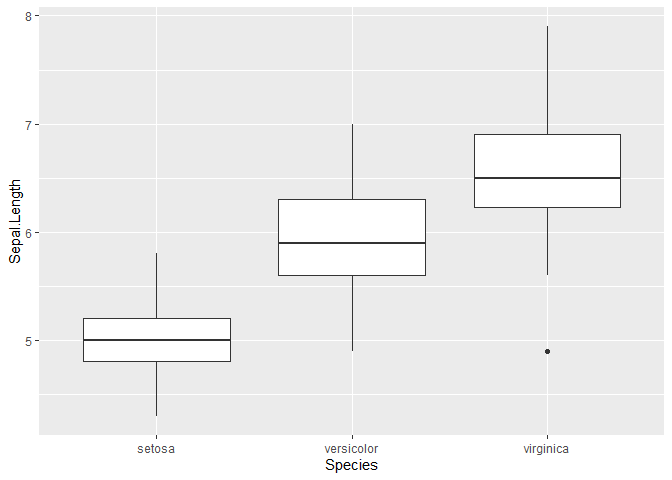

```r
ggplot(iris, aes(x = Species, y = Sepal.Length)) +
  geom_boxplot()
```

Data tidying and shaping. Helps you pivot, separate, join, and organize data structures.

Cool stuff you can do!

```r
pivot <- pivot_longer(airquality,
             cols = c(Ozone, Wind),
             names_to = "variable",
             values_to = "value")
head(pivot)
```

```
# A tibble: 6 × 6
  Solar.R  Temp Month   Day variable value
    <int> <int> <int> <int> <chr>    <dbl>
1     190    67     5     1 Ozone     41
2     190    67     5     1 Wind       7.4
3     118    72     5     2 Ozone     36
4     118    72     5     2 Wind       8
5     149    74     5     3 Ozone     12
6     149    74     5     3 Wind      12.6
```

Reads in data files (like CSVs).

Cool stuff you can do!

```r
# Example using a built-in readr dataset
read_csv(readr_example("mtcars.csv"))
```

```
# A tibble: 32 × 11
     mpg   cyl  disp    hp  drat    wt  qsec    vs    am  gear  carb
   <dbl> <dbl> <dbl> <dbl> <dbl> <dbl> <dbl> <dbl> <dbl> <dbl> <dbl>
 1  21       6  160    110  3.9   2.62  16.5     0     1     4     4
 2  21       6  160    110  3.9   2.88  17.0     0     1     4     4
 3  22.8     4  108     93  3.85  2.32  18.6     1     1     4     1
 4  21.4     6  258    110  3.08  3.22  19.4     1     0     3     1
 5  18.7     8  360    175  3.15  3.44  17.0     0     0     3     2
 6  18.1     6  225    105  2.76  3.46  20.2     1     0     3     1
 7  14.3     8  360    245  3.21  3.57  15.8     0     0     3     4
 8  24.4     4  147.    62  3.69  3.19  20       1     0     4     2
 9  22.8     4  141.    95  3.92  3.15  22.9     1     0     4     2
10  19.2     6  168.   123  3.92  3.44  18.3     1     0     4     4
# ℹ 22 more rows
```

Creates a more modern version of a dataframe that is cleaner and easier to use.

Cool stuff you can do!

```r
tibble(
  x = 1:5,
  y = x^2
)
```

```
# A tibble: 5 × 2
      x     y
  <int> <dbl>
1     1     1
2     2     4
3     3     9
4     4    16
5     5    25
```

Works with **cat**egorical variables. Lets you build more customizable plots.

Cool stuff you can do!

```r
fct_reorder(iris$Species, iris$Sepal.Length) %>%
  head()
```

```
[1] setosa setosa setosa setosa setosa setosa
Levels: setosa versicolor virginica
```

Makes it easy to detect, extract, replace, and clean up strings (text data).

Cool stuff you can do!

```r
str_detect(c("apple", "banana", "pear"), "a")
```

```
[1] TRUE TRUE TRUE
```

Lets you repeat operations without writing loops. Great for applying a function to many things at once.

Cool stuff you can do!

```r
map_dbl(1:5, ~ .x^2)
```

```
[1]  1  4  9 16 25
```

Helps you parse, extract, and do math with dates and times.

Cool stuff you can do!

```r
ymd("2024-02-01") + days(10)
```

```
[1] "2024-02-11"
```

## Visualing using {ggplot2}

First, lets load {tidyverse} in our script. We will be using preloaded data from a package called {palmerpenguins} so install then load that into your script as well. The dataset is called **penguins**, lets inspect the data using `head()` and then check how many rows and columns it has using a function we’ve learned previously.

```r
#install and load packages first

head(penguins)
```

```
# A tibble: 6 × 8
  species island    bill_length_mm bill_depth_mm flipper_length_mm body_mass_g
  <fct>   <fct>              <dbl>         <dbl>             <int>       <int>
1 Adelie  Torgersen           39.1          18.7               181        3750
2 Adelie  Torgersen           39.5          17.4               186        3800
3 Adelie  Torgersen           40.3          18                 195        3250
4 Adelie  Torgersen           NA            NA                  NA          NA
5 Adelie  Torgersen           36.7          19.3               193        3450
6 Adelie  Torgersen           39.3          20.6               190        3650
# ℹ 2 more variables: sex <fct>, year <int>
```

**Every `ggplot()` has 3 main components:**

**1. Data:** the data used to produce a plot. If you are using the pipe function `%>%` you can pipe your data into the plot before you use `ggplot()` and you dont have to specify data inside the plot.

Data can be called within `ggplot()`

```r
ggplot(penguins, aes(x = bill_length_mm, y = bill_depth_mm)) +
  geom_point()
```

[output not shown]

or can be piped in

```r
penguins %>%
ggplot(aes(x = bill_length_mm, y = bill_depth_mm)) +
  geom_point()
```

[output not shown]

**2. Aesthetic mappings:** this is achieved using the `aes()` function within `ggplot()`. it specifies how variables in the data are mapped to visual properties.

**Some visual properties include:**

- x
- y
- color
- fill
- alpha
- others (linetype, shape, linewidth, size, group)

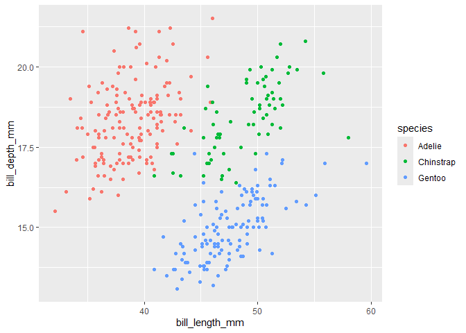

```r
ggplot(penguins, aes(x = bill_length_mm, y = bill_depth_mm, color = species)) +
  geom_point()
```

*Exercise 1.* play around with the `aes()` function in the ggplot above, use some other aes mapping like alpha = to see what it does.

3. **Layer(s):** this is usually achieved using `geom_*()` and adding additional layers on top. You will use a `geom_*()` function to represent data points. some `geom_*()` functions include:

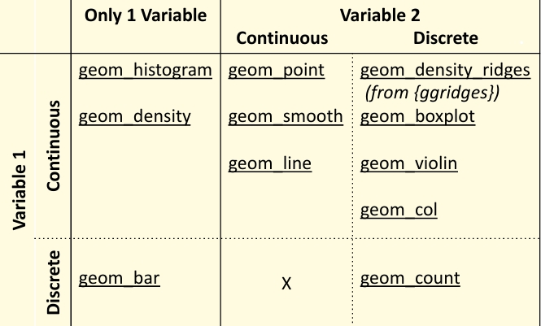

geom_*() Functions

*note.* within ggplot, you need to use `+` instead of `%>%` to add layers, its just the syntax.

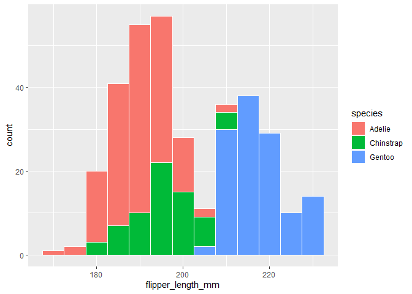

```r
ggplot(penguins, aes(x = flipper_length_mm, fill = species)) + #for a histogram, need to specify fill in aes() and no Y-axis
  geom_histogram(binwidth = 5, color = "white")
```

You can also use the `aes()` function in different layers within `ggplot()`.

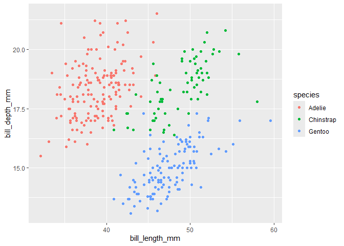

```r
ggplot(penguins, aes(x = bill_length_mm, y = bill_depth_mm)) +
  geom_point(aes(color = species))
```

*Exercise 2.* I want to add a layer to the ggplot above that adds a line by species. Add a geom layer called `geom_smooth()` and using `aes()` inside the `geom_smooth()` use linetype = to specify you want the lines to use linetype by species.

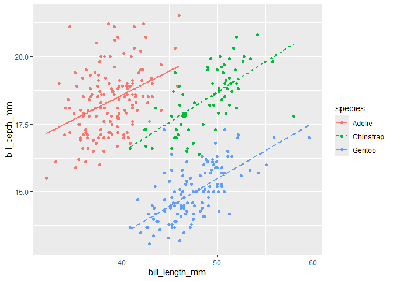

```r
ggplot(penguins, aes(x = bill_length_mm, y = bill_depth_mm)) +
  geom_point(aes(color = species))+
  geom_smooth(aes(color = species, linetype = species), method = lm, se = F)
```

## Visualizing aggregated data

Using our Penguins dataset, lets aggregate the data so we can visualize some cool stats! I want to aggregate by species and get the mean body mass per species of pengies.

```r
penguins_bodymass_agg <- penguins %>%
  group_by(species) %>%
  summarize(
    mean_body_mass = mean(body_mass_g, na.rm = T) #whats missing here??
  )

head(penguins_bodymass_agg)
```

```
# A tibble: 3 × 2
  species   mean_body_mass
  <fct>              <dbl>
1 Adelie             3701.
2 Chinstrap          3733.
3 Gentoo             5076.
```

Now lets create a bar plot of body mass per species.

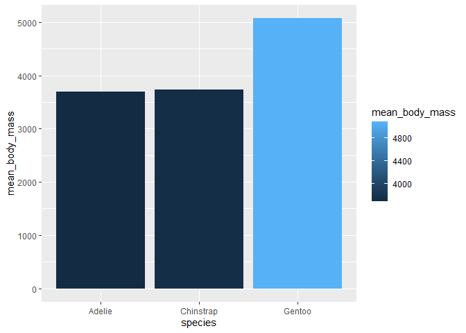

```r
ggplot(penguins_bodymass_agg,
       aes(x = species, y = mean_body_mass, fill = mean_body_mass)) +
  geom_col()
```

This is great, but lets add some more visual context using `labs()` function. `labs()` is used in ggplot, and lets you add a title, axis labels, captions, and labels!

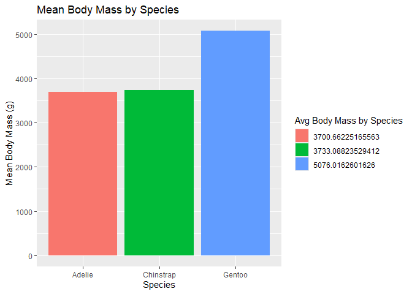

```r
ggplot(penguins_bodymass_agg,
       aes(x = species, y = mean_body_mass, fill = factor(mean_body_mass))) +
  geom_col() +
  labs(
    title = "Mean Body Mass by Species",
    x = "Species",
    y = "Mean Body Mass (g)",
    fill = "Avg Body Mass by Species"
  )
```

You can also change the theme of the figure to look more presentable using `theme_*()`. There are also packages that are made just for fun visual themes, one is called {ggthemes}

*Exercise 3.* Look up online a list of different themes in {ggthemes} you can add in ggplot(). Install then load in this package and pick a theme you like and use it!

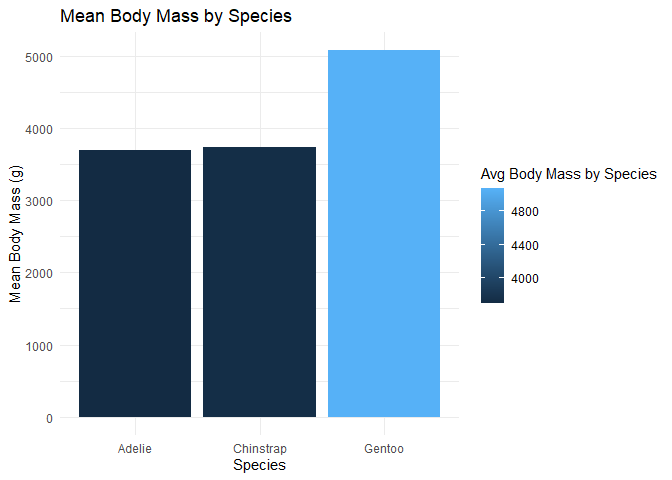

```r
ggplot(penguins_bodymass_agg,
       aes(x = species, y = mean_body_mass, fill = mean_body_mass)) +
  geom_col() +
  labs(
    title = "Mean Body Mass by Species",
    x = "Species",
    y = "Mean Body Mass (g)",
    fill = "Avg Body Mass by Species"
  ) +
  theme_minimal() #replace with a theme of your choosing!
```

*Exercise 4.* I want to aggregate by species and island. To a new object, use the penguins data and `group_by()` species and island, then `summarize()` the mean body mass of penguins AND the mean flipper length of penguins. name these mean_mass and mean_flipper in the summarize function.

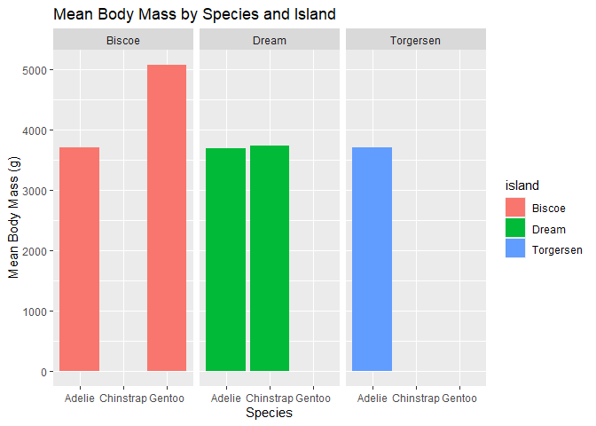

```r
ggplot(penguins_s_i,
       aes(x = species, y = mean_mass, fill = island)) +
  geom_col(position = "dodge") +
  facet_wrap(~ island) +
  labs(
    title = "Mean Body Mass by Species and Island",
    x = "Species",
    y = "Mean Body Mass (g)"
  )
```

There are many more cool things you can add to a ggplot plot, the internet is your friend for all the customizable ways you can use this function!

## Problem Set 6

**1.** Create a scatterplot of flipper_length_mm (x‑axis) vs body_mass_g (y‑axis) using the penguins dataset. Color the points by species and add a title using `labs()`

**2.** Using bill length and bill depth:

- Create a scatterplot
- Add a `geom_smooth()` layer
- Use linetype = species inside the `geom_smooth()` layer
- Turn off the confidence interval `(se = FALSE)`

**3.** Make a histogram of flipper_length_mm:

- Use fill = species
- Set binwidth = 5
- Add a white border around bars (color = “white”)